## a. Produce a scatterplot matrix which includes all the variables in the dataset

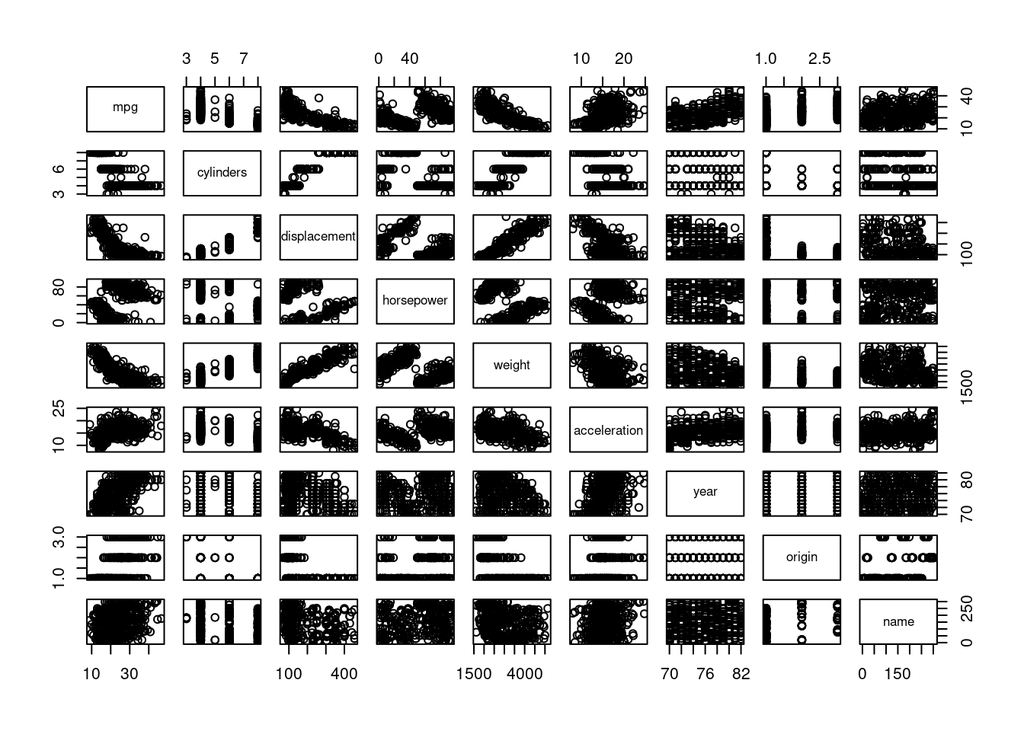

```r
auto <- read.csv("/home/beeps/rtmp/external/eco/noce/islr/labs/3/data/auto.csv")
auto = na.omit(auto)
plot(auto)
```

## b. Compute the matrix of correlations between the variables using the function `cor()`. Exclude the name variable, which is qualitative.

First preprocess the data to remove rows like * sapply: applies the function mapping all values of auto to a numeric value. - Non numerics are converted to NA. * subset: drops the name column, which is all NA * na.omit: omits other rows that have NA because of spurious data entries

```r
auto[33,]
```

```
##    mpg cylinders displacement horsepower weight acceleration year origin
## 33  25         4           98          ?   2046           19   71      1
##          name
## 33 ford pinto
```

```r
auto_clean <- na.omit(subset(data.frame(sapply(auto, function(x) as.numeric(x))), select=-name))
cor(auto_clean)
```

```
##                     mpg  cylinders displacement horsepower     weight
## mpg           1.0000000 -0.7776175   -0.8051269 -0.7784268 -0.8322442
## cylinders    -0.7776175  1.0000000    0.9508233  0.8429834  0.8975273
## displacement -0.8051269  0.9508233    1.0000000  0.8972570  0.9329944
## horsepower   -0.7784268  0.8429834    0.8972570  1.0000000  0.8645377
## weight       -0.8322442  0.8975273    0.9329944  0.8645377  1.0000000
## acceleration  0.4233285 -0.5046834   -0.5438005 -0.6891955 -0.4168392
## year          0.5805410 -0.3456474   -0.3698552 -0.4163615 -0.3091199
## origin        0.5652088 -0.5689316   -0.6145351 -0.4551715 -0.5850054
##              acceleration       year     origin
## mpg             0.4233285  0.5805410  0.5652088
## cylinders      -0.5046834 -0.3456474 -0.5689316
## displacement   -0.5438005 -0.3698552 -0.6145351
## horsepower     -0.6891955 -0.4163615 -0.4551715
## weight         -0.4168392 -0.3091199 -0.5850054
## acceleration    1.0000000  0.2903161  0.2127458
## year            0.2903161  1.0000000  0.1815277
## origin          0.2127458  0.1815277  1.0000000
```

## c. Use the lm function to perform a multiple linear regression with the mpg as the response and all other variables except name as the predictors

```r
lm.ols = lm(mpg~., data=auto_clean)
summary(lm.ols)
```

```
##
## Call:
## lm(formula = mpg ~ ., data = auto_clean)
##
## Residuals:
##     Min      1Q  Median      3Q     Max
## -9.5903 -2.1565 -0.1169  1.8690 13.0604
##
## Coefficients:
##                Estimate Std. Error t value Pr(>|t|)
## (Intercept)  -17.218435   4.644294  -3.707  0.00024 ***
## cylinders     -0.493376   0.323282  -1.526  0.12780
## displacement   0.019896   0.007515   2.647  0.00844 **
## horsepower    -0.016951   0.013787  -1.230  0.21963
## weight        -0.006474   0.000652  -9.929  < 2e-16 ***
## acceleration   0.080576   0.098845   0.815  0.41548
## year           0.750773   0.050973  14.729  < 2e-16 ***
## origin         1.426141   0.278136   5.127 4.67e-07 ***
## ---
## Signif. codes:  0 '***' 0.001 '**' 0.01 '*' 0.05 '.' 0.1 ' ' 1
##
## Residual standard error: 3.328 on 384 degrees of freedom
## Multiple R-squared:  0.8215, Adjusted R-squared:  0.8182
## F-statistic: 252.4 on 7 and 384 DF,  p-value: < 2.2e-16
```

1. Is there a relationship between the predictors and the response

Yes, high F statistic with a low p value

2. Which predictors appear to have a statistically significant relationship to the response

3. What does the coefficient for the year variable suggest

It suggests that newer cards have higher mpg (positive correlation). More specifically, for every one year, cards became more fuel efficient by 0.75.

Whereas the coefficient of weight suggests that heavier cars have a lower miles per gallon.

## d. Use the plot() function to produce diagnostic plots of the linear regression fit.

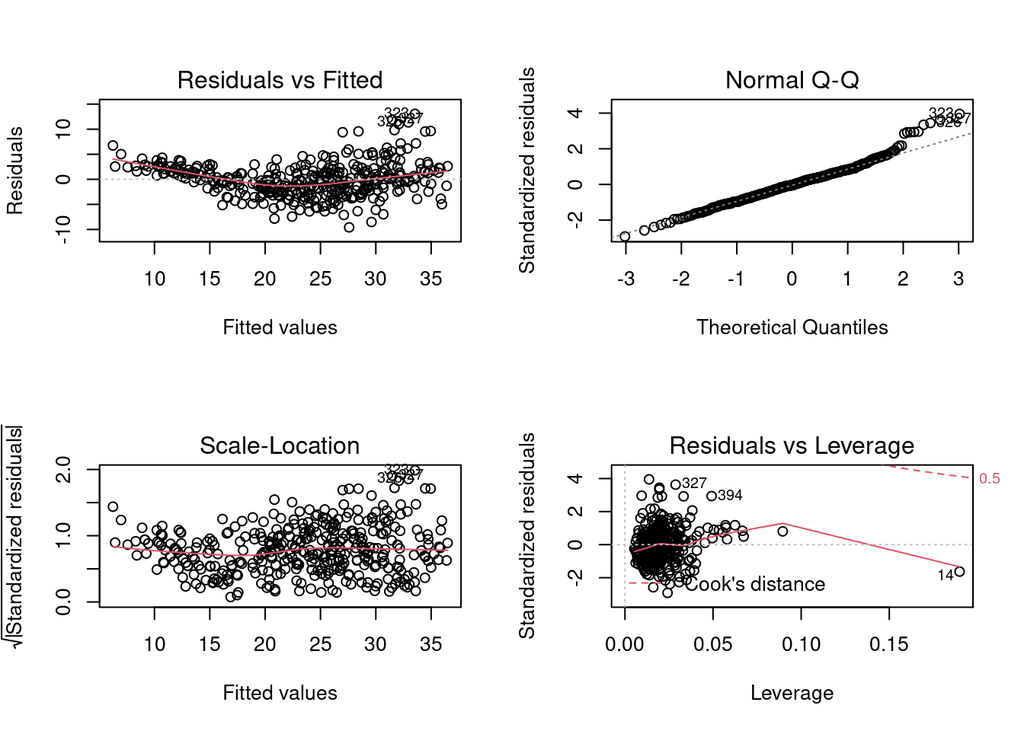

```r
par(mfrow=c(2,2))
plot(lm.ols)
```

1. Comment on any problems you see with the fit.

Evidence of non-linearity. The curve patter of the residual plot shows the function is non linear.

2. Do the residual plots suggest any unusually large outliers?
3. Does the leverage plot identify any observations with unusually high leverage?

1. plot the cooks distance cutoff with `abline`

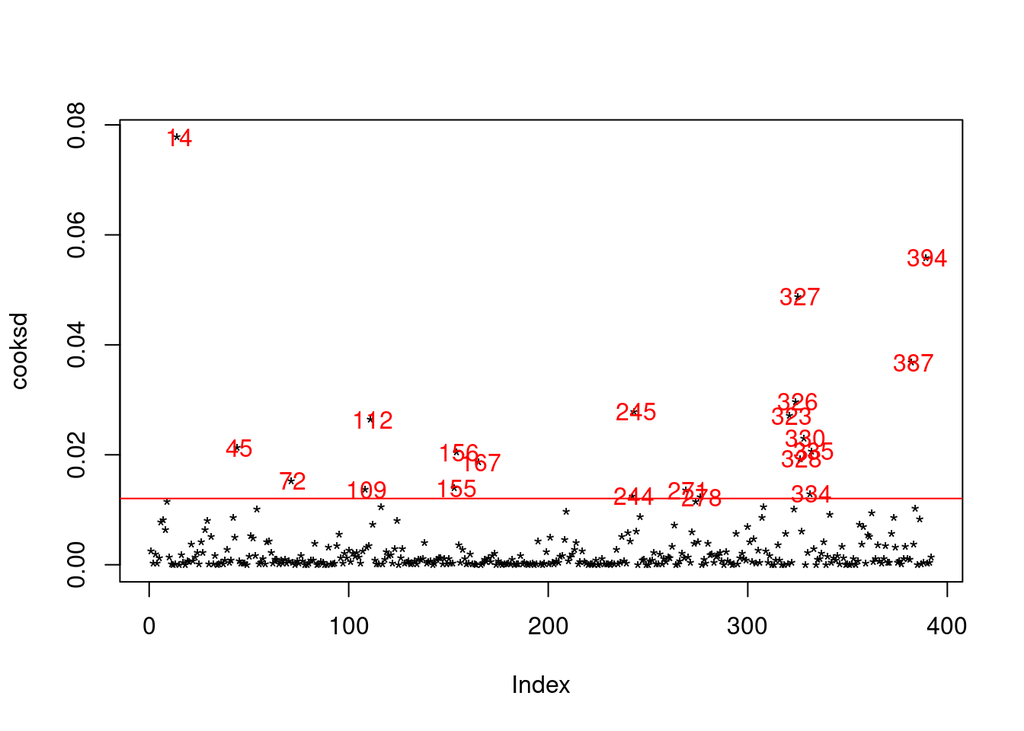

```r
cooksd <- cooks.distance(lm.ols)
plot(cooksd, pch="*")
# Plot cutoff line at 4 * mean(cookds)
abline(h = 4*mean(cooksd, na.rm=T), col="red")
# Plot labels only if above abline
text(x=1:length(cooksd) + 1, y=cooksd, labels=ifelse(cooksd>4*mean(cooksd, na.rm=T), names(cooksd), ""), col="red")
```

2. plot the studentized residual, values > 3 on the absolute scale are classified outliers.

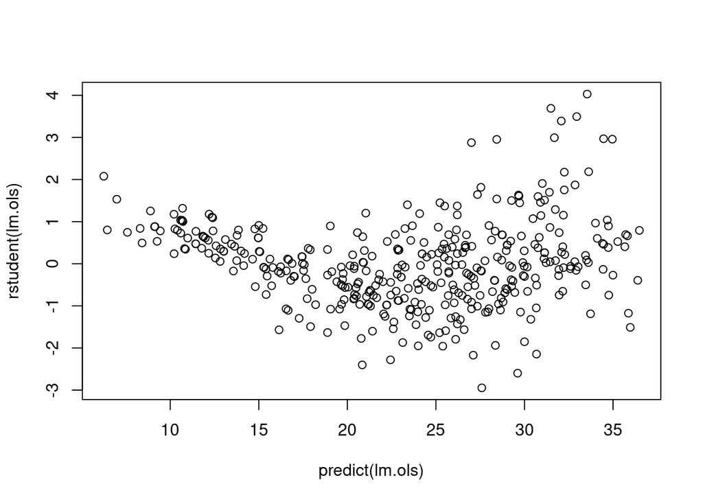

```r
plot(predict(lm.ols), rstudent(lm.ols))
```

## e. Use the * and : symbols to fit linear regression models with interaction effects.

```r
summary(lm(mpg~displacement*cylinders+displacement*weight, data=auto))
```

```
##
## Call:
## lm(formula = mpg ~ displacement * cylinders + displacement *
##     weight, data = auto)
##
## Residuals:
##      Min       1Q   Median       3Q      Max
## -13.3564  -2.4882  -0.3635   1.8469  17.8176
##
## Coefficients:
##                          Estimate Std. Error t value Pr(>|t|)
## (Intercept)             5.285e+01  2.233e+00  23.673  < 2e-16 ***
## displacement           -7.514e-02  1.669e-02  -4.502 8.90e-06 ***
## cylinders               7.580e-01  7.645e-01   0.992    0.322
## weight                 -9.931e-03  1.323e-03  -7.505 4.19e-13 ***
## displacement:cylinders -2.893e-03  3.424e-03  -0.845    0.399
## displacement:weight     2.147e-05  4.996e-06   4.298 2.18e-05 ***
## ---
## Signif. codes:  0 '***' 0.001 '**' 0.01 '*' 0.05 '.' 0.1 ' ' 1
##
## Residual standard error: 4.115 on 391 degrees of freedom
## Multiple R-squared:  0.7269, Adjusted R-squared:  0.7234
## F-statistic: 208.2 on 5 and 391 DF,  p-value: < 2.2e-16
```

Do any interactions appear to be statistically significant?

One way to pick the terms for interaction is via correlation matrix. It looks like displacement:weight is significant while the interaction between displacement and cylinders is not.

6. Try a few different transformations of the variables such as log(x), root(x), x^2
- One applies root, log against skewed transformations (roots are weaker)

```r
summary(lm(mpg~log(weight)+sqrt(horsepower)+acceleration+I(acceleration^2), data=auto_clean))
```

```
##
## Call:
## lm(formula = mpg ~ log(weight) + sqrt(horsepower) + acceleration +
##     I(acceleration^2), data = auto_clean)
##
## Residuals:
##      Min       1Q   Median       3Q      Max
## -11.2932  -2.5082  -0.2237   2.0237  15.7650
##
## Coefficients:
##                    Estimate Std. Error t value Pr(>|t|)
## (Intercept)       178.30303   10.80451  16.503  < 2e-16 ***
## log(weight)       -14.74259    1.73994  -8.473 5.06e-16 ***
## sqrt(horsepower)   -1.85192    0.36005  -5.144 4.29e-07 ***
## acceleration       -2.19890    0.63903  -3.441 0.000643 ***
## I(acceleration^2)   0.06139    0.01857   3.305 0.001037 **
## ---
## Signif. codes:  0 '***' 0.001 '**' 0.01 '*' 0.05 '.' 0.1 ' ' 1
##
## Residual standard error: 3.99 on 387 degrees of freedom
## Multiple R-squared:  0.7414, Adjusted R-squared:  0.7387
## F-statistic: 277.3 on 4 and 387 DF,  p-value: < 2.2e-16
```

- Worse R squared and better F than the regular OLS
- The residual vs fitted values show indications of heteroskedasticity (non uniform varience of residuals around the mean of the residuals - cone shaped, initially low, increasing)
- Multiple variables show an l like form when plotted against y, indicating that it might be better to take a log on the response variable (mpg) instead

```r
summary(lm(log(mpg)~., data=auto_clean))
```

```
##
## Call:
## lm(formula = log(mpg) ~ ., data = auto_clean)
##
## Residuals:
##      Min       1Q   Median       3Q      Max
## -0.40955 -0.06533  0.00079  0.06785  0.33925
##
## Coefficients:
##                Estimate Std. Error t value Pr(>|t|)
## (Intercept)   1.751e+00  1.662e-01  10.533  < 2e-16 ***
## cylinders    -2.795e-02  1.157e-02  -2.415  0.01619 *
## displacement  6.362e-04  2.690e-04   2.365  0.01852 *
## horsepower   -1.475e-03  4.935e-04  -2.989  0.00298 **
## weight       -2.551e-04  2.334e-05 -10.931  < 2e-16 ***
## acceleration -1.348e-03  3.538e-03  -0.381  0.70339
## year          2.958e-02  1.824e-03  16.211  < 2e-16 ***
## origin        4.071e-02  9.955e-03   4.089 5.28e-05 ***
## ---
## Signif. codes:  0 '***' 0.001 '**' 0.01 '*' 0.05 '.' 0.1 ' ' 1
##
## Residual standard error: 0.1191 on 384 degrees of freedom
## Multiple R-squared:  0.8795, Adjusted R-squared:  0.8773
## F-statistic: 400.4 on 7 and 384 DF,  p-value: < 2.2e-16
```

- This shows better R squared and F than the regular ols
- There is also no longer any evidence of hetereskedascity around the mean of the residuals